# Census Income

# Preface

For the final exam/project we will develop classification models using several approaches and compare their performance on a new dataset – so-called “Census Income” from UCI ML. It is available at UCI ML web site, but so that we are not at the mercy of UCI ML availability, there is also a local copy of it in our website in Canvas as a zip-archive of all associated files. Among other things, the description for this dataset also presents performance (prediction accuracy) observed by the dataset providers using variety of modeling techniques – this supplies a context for the errors of the models we will develop here.

Please note that the original data has been split up into training and test subsets, but there doesn’t seem to be anything particular about that split, so we might want to pool those two datasets together and split them into training and test as necessary ourselves. As you do that, please check that the attribute levels are consistent between those two files. For instance, the categorized income levels are indicated using slightly different notation in their training and test data. By now it should be quite straightforward for you to correct that when you pool them together.

Also, please note that there is non-negligible number of rows with missing values that for most analyses cannot be included without modification in the computation. Please decide how you want to handle them and proceed accordingly. The simplest and perfectly acceptable approach would be to exclude those observations from the rest of the analyses, but if you have time and inclination to investigate the impact of imputing them by various means, you are welcome to try.

Attribute called “final weight” in the dataset description represents demographic weighting of these observations. Please disregard it for the purposes of this assignment.

Additionally, several attributes in this dataset are categorical variables with more than two levels (e.g. native country, occupation, etc.). Please make sure to translate them into corresponding sets of dummy indicator variables for the methods that require such conversion (e.g. PCA) – R function `model.matrix` can be convenient for this, instead of generating those 0/1 indicators for each level of the factor manually (which is still perfectly fine). Some of those multi-level factors contain very sparsely populated categories – e.g. occupation “Armed-Forces” or work class “Never-worked” – it is your call whether you want to keep those observations in the data or exclude also on the basis that there is not enough data to adequately capture the impact of those categories. Feel free to experiment away!

Among the multi-level categorical attributes, native country attribute has the largest number of levels – several folds higher than any other attribute in this dataset – some of which have relatively few observations. This associated increase in dimensionality of the data may not be accompanied by a corresponding gain of resolution – e.g. would we expect this data to support the *difference* in income between descendants from Peru and Nicaragua, for example, or from Cambodia and Laos? Please feel free to evaluate the impact of inclusion and/or omission of this attribute in/from the model and/or discretizing it differently (e.g. US/non-US, etc.).

Lastly, the size of this dataset can make some of the modeling techniques run slower than what we were typically encountering in this class. You may find it helpful to do some of the exploration and model tuning on multiple random samples of smaller size as you decide on useful ranges of parameters/modeling choices, and then only perform a final run of fully debugged and working code on the full dataset. Please see also the afterword below on the computational demands of this problem set.

```r
#Loading "adult.data" as dataset of attribte class of characters
#Loading "adult.test" as dataset of attribte class of characters; skiping first row
train.data.tmp = read.table('adult.data', sep = ',', header=F, colClasses = c("character"), strip.white=T)
test.data.tmp = read.table('adult.test', sep = ',', skip=1, header=F, colClasses = c("character"), strip.white=T)

#Correcting income variable in test.data.tmp dataset
test.data.tmp[,15] = ifelse(test.data.tmp[,15] == ">50K.", ">50K", "<=50K")

#rBinding datasets
data = rbind(train.data.tmp,test.data.tmp)

#Setting colnames
colnames(data) = c("age", "workclass", "fnlwgt", "educ", "educNum", "mariStatus", "occupation",
                   "relShip", "race", "sex", "capGain", "capLoss", "hpw", "natCountry", "income")


#Setting all unknown values to NA
#Removing observations that include at least one NA
data[data == "?"] = NA
data = data[complete.cases(data), ]

#Removing observation that have only few observations for categories
data = subset(data,
                workclass != "Without-pay" &
                occupation != "Armed-Forces")

#nat_country - groupping all observations that are not from US, in non-US
data$natCountry = ifelse(data$natCountry == "United-States", "US", "non-US")

#Categorical/Continuous Variables
con.att = c("age","educNum","capGain","capLoss","hpw")
cat.att = setdiff(colnames(data),con.att)

#Converting attributes to integer for continiuous and factor categorical variables
for(coln in colnames(data)) {
  if (coln %in% con.att) {
    data[,coln] = as.integer(data[,coln])
  } else {
    data[,coln] = factor(data[,coln])
  }
}

#Decreasing levels of multilevel categorical attributes
levels(data$occupation) = c("Other","Other","ExecMng","Other","Other","Other","Service",
                    "Service","Profi","Service","Other","Service","Other")
levels(data$mariStatus) = c("Divorced","Married","Married","Married","NeverMarried","Separated","Widowed")
levels(data$workclass) = c("Gov","Gov","Private","SEinc","SEnotInc","Gov")


#Setting capGain = capGain-capLoss - to decrease dimensions
data$capGain = data$capGain - data$capLoss

#Excluding "fnlwgt" from dataset
#Excluding "educ" from dataset, since it can be obtained from educ_num
#Excluding "capLoss" from dataset
data = data[,c(-3,-4,-12)]

#Resetting list of categorical/continuous  variables
con.att = c("age","educNum","capGain","hpw")
cat.att = setdiff(colnames(data),con.att)


dim(data)
```

```
## [1] 45187    12
```

```r
summPreds <- function(inpPred,inpTruth,inpMetrNms=c("err","acc","sens","spec")) {
  retVals <- numeric()
  for ( metrTmp in inpMetrNms ) {
    retVals[metrTmp] <- performance(prediction(inpPred,inpTruth),measure=metrTmp)@y.values[[1]][2]
  }
  retVals
}

rocplot=function(pred, truth, ...) {
  predob = prediction(pred, truth)
  perf = performance(predob, "tpr", "fpr")
  plot(perf,...)
}


#Number of simulations/resamplings
nSim = 20

#Error rates for different methods from data description
methTmp = c("C4.5-auto",
#            "ID3 (0.6)",
#            "ID3 (0.8)",
#            "T2",
            "1R",
            "NBTree",
#            "CN2",
            "HOODG",
            "FSS NB",
#            "IDTM",
            "NB",
            "KNN (1)"#,
#            "KNN (3)",
#            "OC1"
)
valTmp =  c(14.46,
#            15.64,
#            16.47,
#            16.84,
            19.54,
            14.10,
#            16.00,
            14.82,
            14.05,
#            14.46,
            16.12,
            21.42#,
#            20.35#,
#            15.04
)
dfTmp = data.frame(type=methTmp,metric="err",value=valTmp/100)
dfTmp = rbind(dfTmp,data.frame(type=methTmp,metric="acc",value=1-valTmp/100))

#data = data[sample(nrow(data),0.1*nrow(data)),]
```

# Problem 1: univariate and unsupervised analysis

Download and read “Census Income” data into R and prepare graphical and numerical summaries of it: e.g. histograms of continuous attributes, contingency tables of categorical variables, scatterplots of continuous attributes with some of the categorical variables indicated by color/symbol shape, etc. Perform principal components analysis of this data (do you need to scale it prior to that? how would you represent multilevel categorical attributes to be used as inputs for PCA?) and plot observations in the space of the first few principal components with subjects’ gender and/or categorized income indicated by color/shape of the symbol. Perform univariate assessment of associations between outcome we will be modeling and each of the attributes (e.g. t-test or logistic regression for continuous attributes, contingency tables/Fisher exact test/$\chi^2$ test for categorical attributes). Summarize your observations from these assessments: does it appear that there is association between outcome and predictors? Which predictors seem to be more/less relevant?

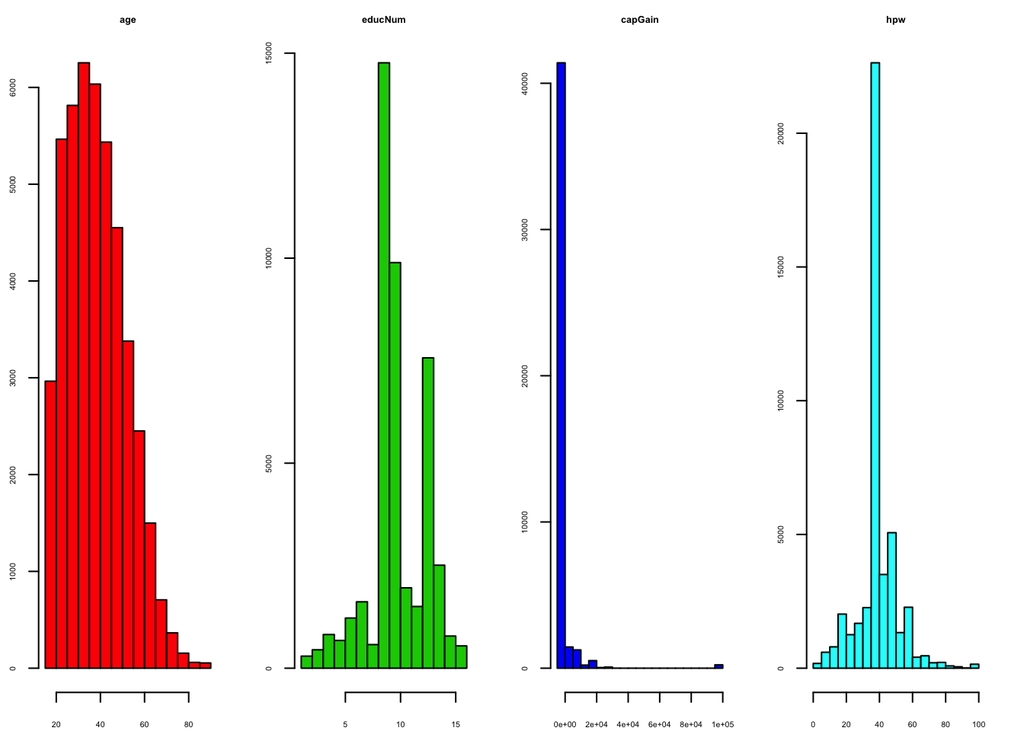

```r
#Data analysis
#Continuous variables histogram
old.par <- par(mar=c(2,2,2,2),mfrow=c(1,length(con.att)),ps=6)
for(coln in con.att) {
  hist(data[,coln], main = coln, col=which(con.att == coln)+1 )
}
```

```r
par(old.par)
```

Most of the observations are for people aged 20-60 years, 8-14 education years, 0 capital gain, and working 19-60 hours per week. Continuous attributes are not normally distributed.

Categorical variables and income as contingency tables(Chi-test of Categorical variables):

```r
#Categorical variables and income as contingency tables
#Chi-test of Categorical variables
for(coln in setdiff (cat.att, c("income"))) {
  CrossTable(data$income,data[,coln],digits=1,prop.r=F,prop.t=F,prop.chisq=T,chisq=T,format="SPSS", dn=c("income",coln))
}
```

```
##
##    Cell Contents
## |-------------------------|
## |                   Count |
## | Chi-square contribution |
## |          Column Percent |
## |-------------------------|
##
## Total Observations in Table:  45187
##
##              | workclass
##       income |      Gov  |  Private  |    SEinc  | SEnotInc  | Row Total |
## -------------|-----------|-----------|-----------|-----------|-----------|
##        <=50K |     4458  |    26056  |      734  |     2737  |    33985  |
##              |     30.5  |     40.4  |    205.2  |      4.9  |           |
##              |     69.2% |     78.2% |     44.6% |     72.1% |           |
## -------------|-----------|-----------|-----------|-----------|-----------|
##         >50K |     1980  |     7251  |      912  |     1059  |    11202  |
##              |     92.4  |    122.5  |    622.4  |     14.8  |           |
##              |     30.8% |     21.8% |     55.4% |     27.9% |           |
## -------------|-----------|-----------|-----------|-----------|-----------|
## Column Total |     6438  |    33307  |     1646  |     3796  |    45187  |
##              |     14.2% |     73.7% |      3.6% |      8.4% |           |
## -------------|-----------|-----------|-----------|-----------|-----------|
##
##
## Statistics for All Table Factors
##
##
## Pearson's Chi-squared test
## ------------------------------------------------------------
## Chi^2 =  1132.989     d.f. =  3     p =  2.53497e-245
##
##
##
##        Minimum expected frequency: 408.0486
##
##
##    Cell Contents
## |-------------------------|
```

[output cut: 209 more lines]

```
##
##
## Statistics for All Table Factors
##
##
## Pearson's Chi-squared test
## ------------------------------------------------------------
## Chi^2 =  68.47653     d.f. =  1     p =  1.283968e-16
##
## Pearson's Chi-squared test with Yates' continuity correction
## ------------------------------------------------------------
## Chi^2 =  68.15694     d.f. =  1     p =  1.509874e-16
##
##
##        Minimum expected frequency: 974.0115
```

Since we can see significantly different proportions of income >50K for different levels of categorical variables, workclass::SEinc, occupation::ExecMng, occupation::Profi, mariStatus::Married(NOT sex::Female), race::Asian-Pac-Islander, race::White and some other levels are more significant for predicting income.

Continuous attributes:

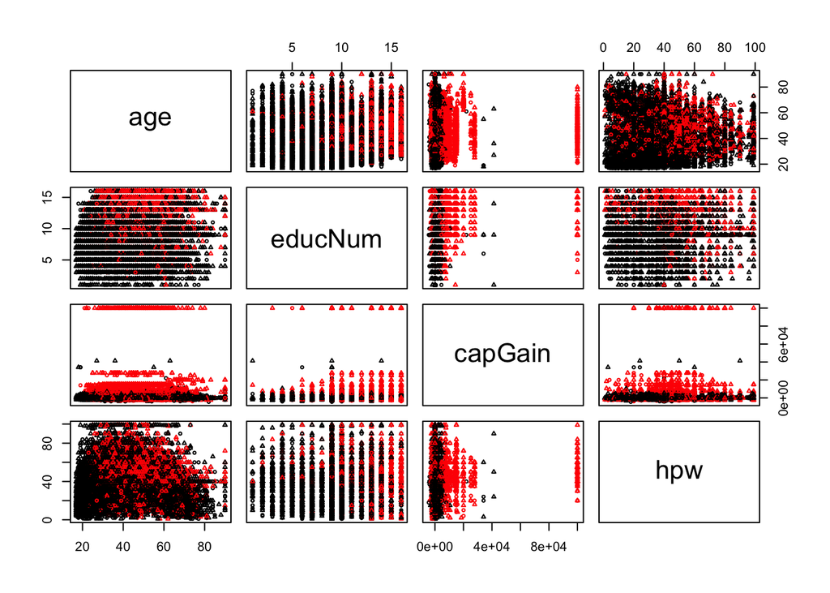

```r
#Scatterplots of continuous attributes; differentiating income and sex;
pairs(data[,con.att], col=as.numeric(data$income), pch=as.numeric(data$sex), cex=0.5)
```

From scatterplots it seems to be a correlation between years of education and income - after certain number of years of education income probably be above 50K. Also, from the scatterplot for age and years of education we can see that middle-aged people with years of education more than 12 years will probably have income > 50K.

Scatterplotting some relevant attributes:

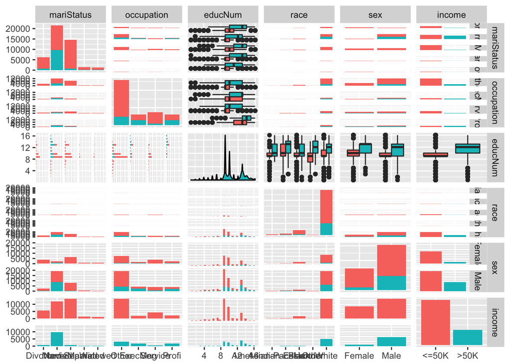

```r
#Other relevant attributes
ggpairs(data[,c("mariStatus","occupation","educNum","race","sex","income")],aes(colour=income))
```

#### PCA

To correctly explain variance of each component we will need to scale attributes. Multilevel categorical attributes in PCA will be represented as additional attribute for each category and intercept using `model.matrix`.

```r
#PCA
dataTmp = data[order(data$sex, decreasing=T),]
#dataTmp = dataTmp[order(dataTmp$income),]

pca.formula = as.formula(paste0("~0+",paste0( setdiff(colnames(data),c("income")), collapse = "+")))
data.pca = as.data.frame(model.matrix(pca.formula,data=dataTmp))

pca = prcomp(data.pca,scale=T)
summary(pca)
```

```
## Importance of components:
##                           PC1     PC2     PC3     PC4     PC5    PC6
## Standard deviation     1.7772 1.45630 1.39229 1.30141 1.22220 1.1849
## Proportion of Variance 0.1215 0.08157 0.07456 0.06514 0.05745 0.0540
## Cumulative Proportion  0.1215 0.20305 0.27761 0.34275 0.40020 0.4542
##                            PC7     PC8     PC9    PC10    PC11   PC12
## Standard deviation     1.15743 1.09192 1.06882 1.03681 1.02856 1.0108
## Proportion of Variance 0.05152 0.04586 0.04394 0.04135 0.04069 0.0393
## Cumulative Proportion  0.50572 0.55158 0.59552 0.63686 0.67755 0.7168
##                           PC13    PC14    PC15    PC16    PC17    PC18
## Standard deviation     0.99685 0.99458 0.94619 0.92286 0.87977 0.83263
## Proportion of Variance 0.03822 0.03805 0.03443 0.03276 0.02977 0.02666
## Cumulative Proportion  0.75507 0.79312 0.82755 0.86031 0.89008 0.91674
##                           PC19    PC20    PC21    PC22    PC23    PC24
## Standard deviation     0.78123 0.70738 0.64154 0.60908 0.45515 0.19710
## Proportion of Variance 0.02347 0.01925 0.01583 0.01427 0.00797 0.00149
## Cumulative Proportion  0.94021 0.95946 0.97529 0.98956 0.99753 0.99902
##                           PC25      PC26
## Standard deviation     0.15960 7.192e-14
## Proportion of Variance 0.00098 0.000e+00
## Cumulative Proportion  1.00000 1.000e+00
```

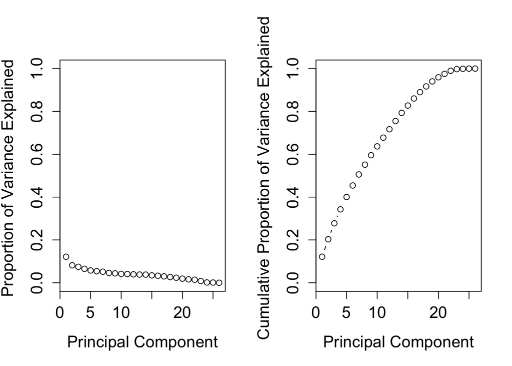

```r
pca.var = (pca$sdev^2)
pve = pca.var/sum(pca.var)
old.par <- par(mfrow=c(1,2),ps=16)
plot(pve, xlab="Principal Component", ylab="Proportion of Variance Explained ", ylim=c(0,1), type='b')
plot(cumsum(pve), xlab="Principal Component", ylab="Cumulative Proportion of Variance Explained ", ylim=c(0,1), type='b')
```

```r
par(old.par)


pc1 = pca$rotation[,"PC1"]; pc1[which.max(abs(pc1))]
```

```
## mariStatusMarried
##         0.4458346
```

```r
pc2 = pca$rotation[,"PC2"]; pc2[which.max(abs(pc2))]
```

```
## raceWhite
## 0.5177194
```

```r
pc3 = pca$rotation[,"PC3"]; pc3[which.max(abs(pc3))]
```

```
## workclassPrivate
##        0.4103504
```

```r
pc4 = pca$rotation[,"PC4"]; pc4[which.max(abs(pc4))]
```

```
## mariStatusWidowed
##        -0.3739184
```

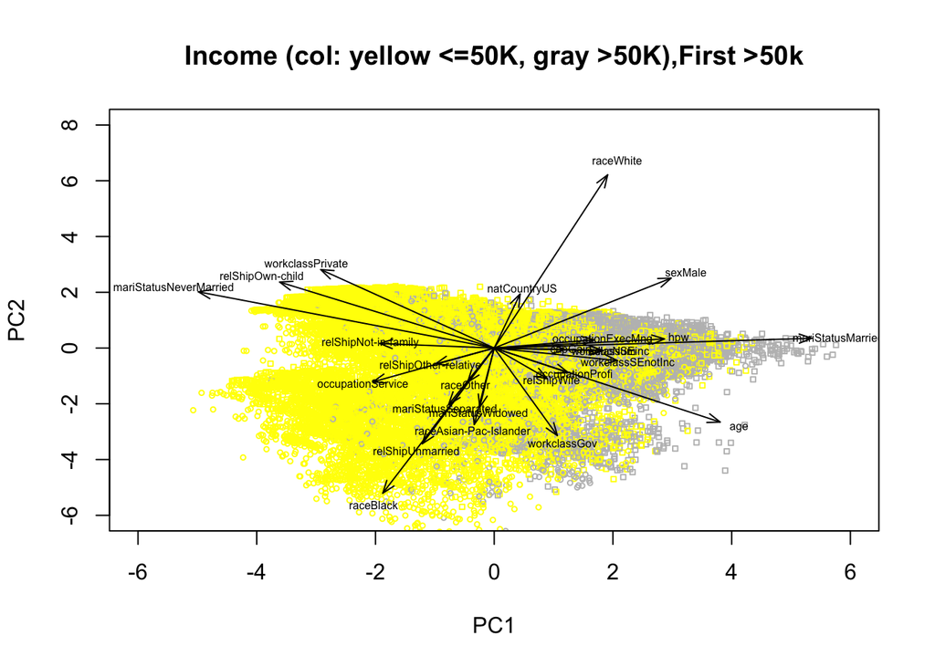

```r
pca.pc12 = pca$x[,1:2]


plot(pca.pc12, main="Income (col: yellow <=50K, gray >50K),First >50k",
     xlim=c(-6,6),ylim=c(-6,8),
     pch=2-as.numeric(dataTmp$sex),
     cex=0.5,
     col=as.numeric(dataTmp$income)+6)
arrows(0,0, pca$rotation[,"PC1"]*12,pca$rotation[,"PC2"]*12,length=0.1, lwd=1,angle=20, col="black")
text(pca$rotation[,"PC1"]*13,pca$rotation[,"PC2"]*13,rownames(pca$rotation), col="black", cex=.5)
```

As we saw above in contingency tables, in biplot we can see that married male with age above or little below the average will probably have income >50K.

Correlations: raceBlack, (negative raceWhite), raceOther, relShipUnmarried, mariStatusSeperated; mariStatusMarried, hpw, occupationExecMng, workclassSE;

```r
#T-test of continuous attributes
for(coln in con.att) {
  print(paste("income,",coln))
  print(t.test(scale(as.numeric(data$income)), scale(data[,coln])))
}
```

```
## [1] "income, age"
##
##  Welch Two Sample t-test
##
## data:  scale(as.numeric(data$income)) and scale(data[, coln])
## t = -2.6931e-14, df = 90372, p-value = 1
## alternative hypothesis: true difference in means is not equal to 0
## 95 percent confidence interval:
##  -0.01303954  0.01303954
## sample estimates:
##     mean of x     mean of y
## -2.286025e-16 -4.943115e-17
##
## [1] "income, educNum"
##
##  Welch Two Sample t-test
##
## data:  scale(as.numeric(data$income)) and scale(data[, coln])
## t = -3.8204e-14, df = 90372, p-value = 1
## alternative hypothesis: true difference in means is not equal to 0
## 95 percent confidence interval:
##  -0.01303954  0.01303954
## sample estimates:
##     mean of x     mean of y
## -2.286025e-16  2.556529e-17
##
## [1] "income, capGain"
##
##  Welch Two Sample t-test
##
## data:  scale(as.numeric(data$income)) and scale(data[, coln])
## t = -3.6279e-14, df = 90372, p-value = 1
## alternative hypothesis: true difference in means is not equal to 0
## 95 percent confidence interval:
##  -0.01303954  0.01303954
## sample estimates:
##     mean of x     mean of y
## -2.286025e-16  1.275664e-17
##
## [1] "income, hpw"
##
##  Welch Two Sample t-test
##
## data:  scale(as.numeric(data$income)) and scale(data[, coln])
## t = -3.2671e-14, df = 90372, p-value = 1
## alternative hypothesis: true difference in means is not equal to 0
## 95 percent confidence interval:
##  -0.01303954  0.01303954
## sample estimates:
##     mean of x     mean of y
## -2.286025e-16 -1.124659e-17
```

Based on CrossTables it seems that predictors mariStatus, workclass/occupation, race, sex, educNum, age more relevant for predicting income.

# Problem 2: logistic regression

Develop logistic regression model of the outcome as a function of multiple predictors in the model. Which variables are significantly associated with the outcome? Test model performance on multiple splits of data into training and test subsets, summarize it in terms of accuracy/error, sensitivity/specificity and compare to the performance of other methods reported in the dataset description.

```r
glmFit = glm(income~., data=data, family = binomial)

glmSumm = summary(glmFit)

glmSumm
```

```
##
## Call:
## glm(formula = income ~ ., family = binomial, data = data)
##
## Deviance Residuals:
##     Min       1Q   Median       3Q      Max
## -4.6438  -0.5664  -0.2173  -0.0373   3.5623
##
## Coefficients:
##                          Estimate Std. Error z value Pr(>|z|)
## (Intercept)            -8.482e+00  2.693e-01 -31.500  < 2e-16 ***
## age                     2.614e-02  1.322e-03  19.771  < 2e-16 ***
## workclassPrivate       -6.426e-03  4.100e-02  -0.157 0.875452
## workclassSEinc          2.033e-01  7.501e-02   2.711 0.006712 **
## workclassSEnotInc      -6.429e-01  5.892e-02 -10.912  < 2e-16 ***
## educNum                 3.133e-01  7.355e-03  42.600  < 2e-16 ***
## mariStatusMarried       7.643e-01  1.378e-01   5.548 2.88e-08 ***
## mariStatusNeverMarried -4.607e-01  7.056e-02  -6.528 6.65e-11 ***
## mariStatusSeparated    -1.356e-02  1.304e-01  -0.104 0.917211
## mariStatusWidowed       1.106e-01  1.249e-01   0.885 0.376111
## occupationExecMng       8.040e-01  4.071e-02  19.748  < 2e-16 ***
## occupationService      -4.491e-02  4.803e-02  -0.935 0.349782
## occupationProfi         5.096e-01  4.652e-02  10.955  < 2e-16 ***
## relShipNot-in-family   -9.675e-01  1.335e-01  -7.247 4.25e-13 ***
## relShipOther-relative  -1.416e+00  1.845e-01  -7.672 1.69e-14 ***
## relShipOwn-child       -1.966e+00  1.658e-01 -11.861  < 2e-16 ***
## relShipUnmarried       -1.216e+00  1.496e-01  -8.125 4.48e-16 ***
## relShipWife             1.104e+00  8.252e-02  13.384  < 2e-16 ***
## raceAsian-Pac-Islander  6.702e-01  1.990e-01   3.368 0.000757 ***
## raceBlack               3.666e-01  1.845e-01   1.988 0.046855 *
## raceOther               4.018e-01  2.668e-01   1.506 0.132073
## raceWhite               5.902e-01  1.757e-01   3.358 0.000784 ***
## sexMale                 7.613e-01  6.259e-02  12.162  < 2e-16 ***
## capGain                 2.431e-04  7.178e-06  33.871  < 2e-16 ***
## hpw                     2.871e-02  1.303e-03  22.033  < 2e-16 ***
## natCountryUS            2.784e-01  6.283e-02   4.430 9.41e-06 ***
## ---
## Signif. codes:  0 '***' 0.001 '**' 0.01 '*' 0.05 '.' 0.1 ' ' 1
##
## (Dispersion parameter for binomial family taken to be 1)
##
##     Null deviance: 50611  on 45186  degrees of freedom
## Residual deviance: 30940  on 45161  degrees of freedom
## AIC: 30992
##
## Number of Fisher Scoring iterations: 7
```

```r
glmSumm$coefficients[glmSumm$coefficients[,'Pr(>|z|)']>0.05,]
```

```
##                         Estimate Std. Error    z value  Pr(>|z|)
## workclassPrivate    -0.006425566 0.04099597 -0.1567365 0.8754525
## mariStatusSeparated -0.013556271 0.13041531 -0.1039469 0.9172115
## mariStatusWidowed    0.110583672 0.12494141  0.8850842 0.3761112
## occupationService   -0.044905811 0.04802698 -0.9350122 0.3497820
## raceOther            0.401780783 0.26679076  1.5059771 0.1320730
```

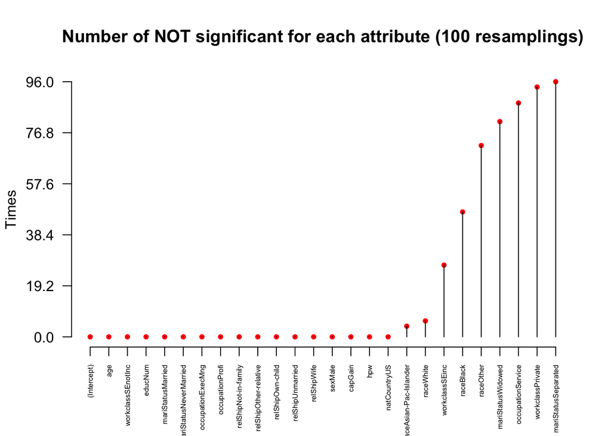

```r
bootPvals = NULL
for ( iBoot in 1:100 ) {
  bootPvals <- rbind(bootPvals,summary(glm(income~.,data=data[sample(nrow(data),nrow(data),replace=TRUE),],family=binomial,control=list(maxit=100)))$coefficients[,'Pr(>|z|)'])
}

glmImp = rowSums(apply(bootPvals,1,function(row) row>0.05))
glmImp = glmImp[order(glmImp)]

old.par = par(no.readonly = TRUE)
plot(glmImp, axes = 0,xlab="",ylab="Times",main="Number of NOT significant for each attribute (100 resamplings)",pch=20,col="red")
lines(glmImp, type="h")
axis(1, at=seq(1,length(names(glmImp)),by=1),labels=names(glmImp),las=2,cex.axis=.5)
axis(2, at=seq(0,ceiling(max(glmImp)),by=ceiling(max(glmImp))/5),las=1)
```

```r
par(old.par)
```

All attributes listed in summary except workclassPrivate, mariStatusSeparated, mariStatusWidowed, occupationService, raceOther are significant for the model with p-values<0.05. Attribute raceBlack is less significant.

```r
glmPred = predict(glmFit, newdata=data, type = "response")>0.5

table(data$income,ifelse(glmPred, ">50K", "<=50K"))
```

```
##
##         <=50K  >50K
##   <=50K 31568  2417
##   >50K   4871  6331
```

```r
summPreds(as.numeric(glmPred)+1,as.numeric(data$income))
```

```
##       err       acc      sens      spec
## 0.1612853 0.8387147 0.5651669 0.9288804
```

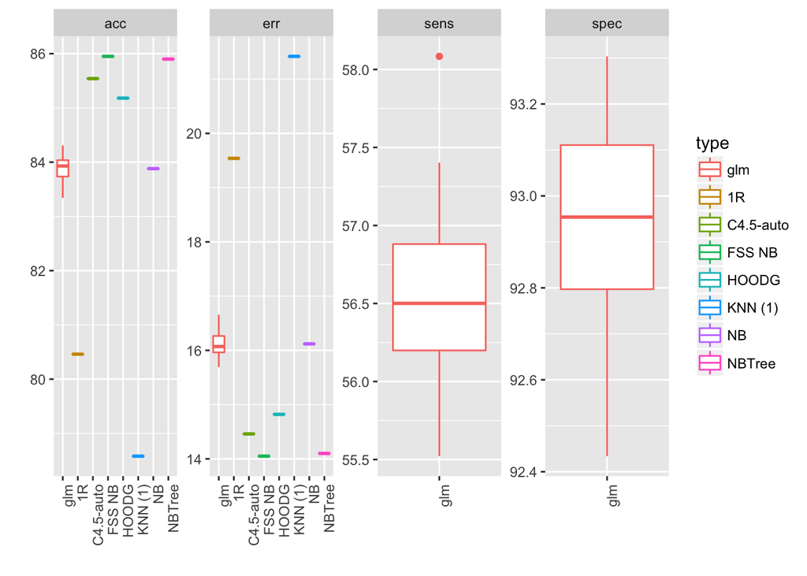

```r
dfGlm <- NULL
for ( iSim in 1:nSim ) {
  trainIdx <- sample(nrow(data),0.67*nrow(data))

  # logistic regression:
  glmTrain <- glm(income~.,data=data[trainIdx,],family=binomial)
  glmTestPred <- predict(glmTrain, newdata=data[-trainIdx,], type="response") > 0.5
  tmpVals <- summPreds(as.numeric(glmTestPred)+1,as.numeric(data[-trainIdx,"income"]))
  dfGlm <- rbind(dfGlm,data.frame(type="glm",metric=names(tmpVals),value=tmpVals))
}
ggplot(rbind(dfGlm,dfTmp),aes(x=type,y=100*value,colour=type)) + geom_boxplot() + facet_wrap(~metric,ncol=4,scales="free") + xlab("") + ylab("") + theme(axis.text.x = element_text(angle = 90, hjust = 1))
```

```r
aggregate(value~metric, data=dfGlm, FUN=function(x) c(mn=mean(x)))
```

```
##   metric     value
## 1    acc 0.8389116
## 2    err 0.1610884
## 3   sens 0.5652269
## 4   spec 0.9293111
```

Logistic regression returned compareable results with other methods reported in the dataset description by about 15% error rate. Only KNN (k=1,3), and 1R returned relatively high error rate by about 20%.

Specificity is much higher than sensitivity by approximetaly 93%, 56% respectively.

# Problem 3: random forest

Develop random forest model of the categorized income. Present variable importance plots and comment on relative importance of different attributes in the model. Did attributes showing up as more important in random forest model also appear as significantly associated with the outcome by logistic regression? Test model performance on multiple splits of data into training and test subsets, compare test and out-of-bag error estimates, summarize model performance in terms of accuracy/error, sensitivity/specificity and compare to the performance of other methods reported in the dataset description.

```r
rfFit = randomForest(income~., data, importance=T)
rfConf = rfFit$confusion
rfConf
```

```
##       <=50K >50K class.error
## <=50K 31956 2029  0.05970281
## >50K   4366 6836  0.38975183
```

```r
1-sum(diag(rfConf[,1:2]))/nrow(data)
```

```
## [1] 0.141523
```

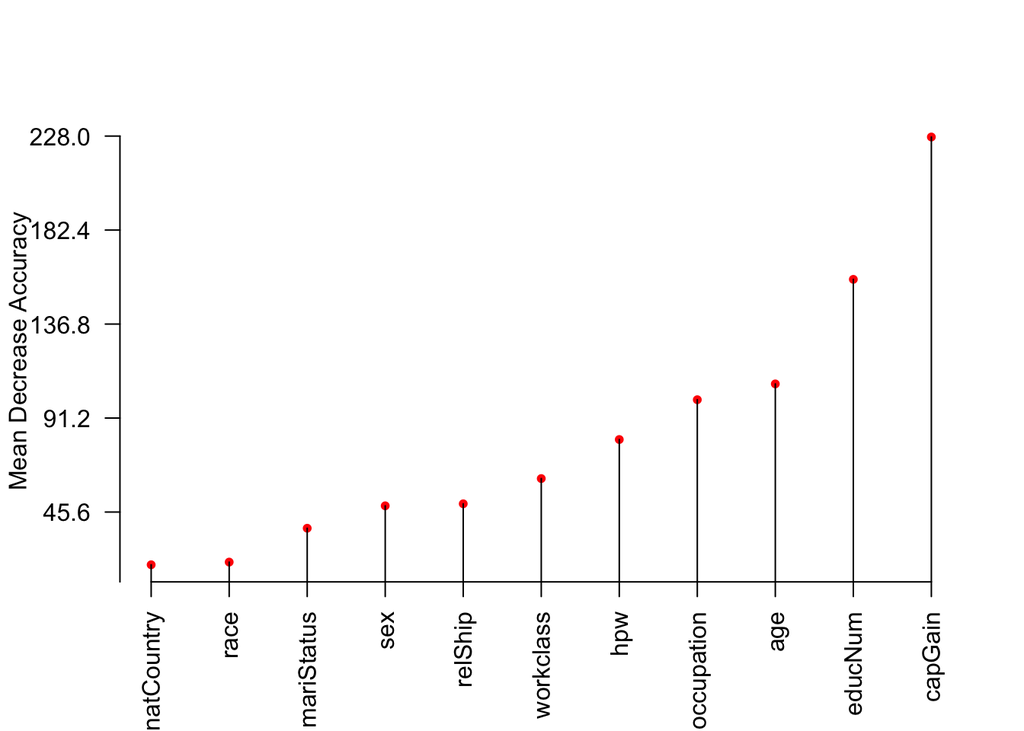

```r
rfImp = importance(rfFit, type=1)[,1]
#plot(factor(names(rfImp)),rfImp)

rfImp = rfImp[order(rfImp)]

old.par = par(no.readonly = TRUE)
plot(rfImp, axes = 0,xlab="",ylab="Mean Decrease Accuracy",pch=20,col="red")
lines(rfImp, type="h")
axis(1, at=seq(1,length(names(rfImp)),by=1),labels=names(rfImp),las=2)
axis(2, at=seq(0,ceiling(max(rfImp)),by=ceiling(max(rfImp))/5),las=1)
```

```r
par(old.par)

rfImp
```

```
## natCountry       race mariStatus        sex    relShip  workclass
##   20.02310   21.32320   37.74564   48.62523   49.60592   61.84195
##        hpw occupation        age    educNum    capGain
##   80.78964  100.09285  107.76954  158.48821  227.55273
```

Random forest have similarly important attributes with logistic regression. Largest mean decrease in accuracy have capGain, educNum, age and occupation.

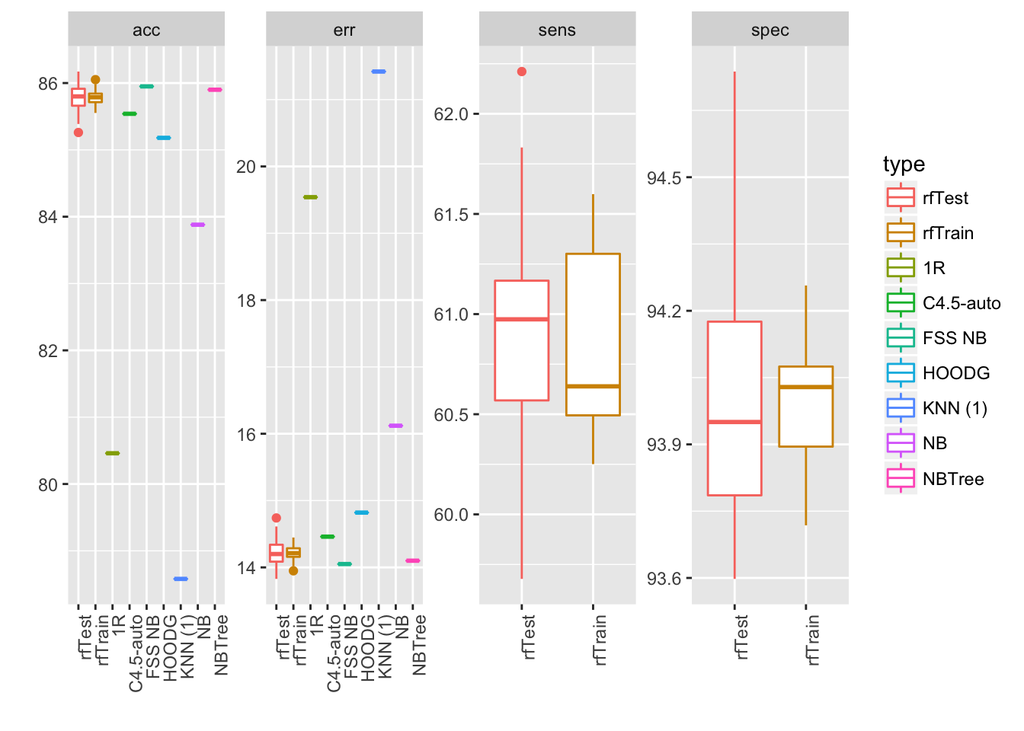

```r
#rfPred = predict(rfFit,newdata=data)
#table(data$income,rfPred)

#summPreds(as.numeric(rfPred),as.numeric(data$income))

dfRf <- NULL
for ( iSim in 1:nSim ) {

  trainIdx <- sample(nrow(data),0.67*nrow(data))

  #RandomForest
  rfTrain = randomForest(income~., data[trainIdx,])



  rfTestPred = predict(rfTrain,newdata=data[-trainIdx,])
  tmpVals = summPreds(as.numeric(rfTestPred),as.numeric(data[-trainIdx,"income"]))
  dfRf = rbind(dfRf,data.frame(type="rfTest",metric=names(tmpVals),value=tmpVals))

  rfOOB = 1-sum(diag(rfTrain$confusion[,1:2]))/nrow(data[trainIdx,])
  tmpVals = c(err=rfOOB,
              acc=1-rfOOB,
              sens=rfTrain$confusion[2,2]/sum(rfTrain$confusion[2,1:2]),
              spec=rfTrain$confusion[1,1]/sum(rfTrain$confusion[1,1:2]))
  dfRf = rbind(dfRf,data.frame(type="rfTrain",metric=names(tmpVals),value=tmpVals))

}
ggplot(rbind(dfRf,dfTmp),aes(x=type,y=100*value,colour=type)) + geom_boxplot() + facet_wrap(~metric,ncol=4,scales="free") + xlab("") + ylab("") + theme(axis.text.x = element_text(angle = 90, hjust = 1))
```

```r
aggregate(value~type+metric, data=dfRf, FUN=function(x) c(mn=mean(x)))
```

```
##      type metric     value
## 1  rfTest    acc 0.8577488
## 2 rfTrain    acc 0.8578150
## 3  rfTest    err 0.1422512
## 4 rfTrain    err 0.1421850
## 5  rfTest   sens 0.6093009
## 6 rfTrain   sens 0.6082809
## 7  rfTest   spec 0.9399159
## 8 rfTrain   spec 0.9399238
```

Random forest returned better results than logistic regression and other methods reported in the dataset description by about 14.2% error rate. Only FSS Naive Bayes and NBTrees returned better results by about 14.1% error rate.

Specificity is much higher than sensitivity by approximetaly 94%, 61% respectively.

Range of OOB error is less than test error. Overall, train error is lower than test error, but still comparable.

# Problem 4: SVM

Develop SVM model of this data choosing parameters (e.g. choice of kernel, cost, etc.) that appear to yield better performance. Test model performance on multiple splits of data into training and test subsets, summarize model performance in terms of accuracy/error, sensitivity/specificity and compare to the performance of other methods reported in the dataset description.

```r
#Running Linear SVM with default parameters
#svmTrain = svm(income~.,data=data,kernel="linear")
#svmPred = predict(svmTrain,newdata=data)
#tmpVals = summPreds(as.numeric(svmPred),as.numeric(data[,"income"]))
#data.frame(type=paste0("svm","Linear",1),metric=names(tmpVals),value=tmpVals)
```

```r
#Calculating best parameters using tune function on entire dataset takes too long, for that reason we will get the most frequent parameters in 10 simulations using tune function on random 10% of the data
#Trying to find better parameters by taking randomly 10% of observation multiple times
tuneParams = NULL
for(i in 1:(nSim/2)) {
  tenProcIdx <- sample(nrow(data),0.1*nrow(data))

  tuneSvm = tune(svm,income~.,data=data[tenProcIdx,],
               ranges=list(kernel=c("linear", "radial", "polynomial"),
                           cost=c(0.1,0.5,1),
                           degree=2:3,
                           gamma=c(0.1,1)))

  tuneParams = rbind(tuneParams, data.frame(tuneSvm$best.parameters[1,],
                                            err=tuneSvm$best.performance))
}

tuneParams
```

```
##         kernel cost degree gamma       err
## 6   polynomial  0.5      2   0.1 0.1463003
## 8       radial  1.0      2   0.1 0.1644512
## 81      radial  1.0      2   0.1 0.1633435
## 82      radial  1.0      2   0.1 0.1671114
## 21  polynomial  0.1      2   1.0 0.1660146
## 9   polynomial  1.0      2   0.1 0.1600185
## 91  polynomial  1.0      2   0.1 0.1598042
## 83      radial  1.0      2   0.1 0.1615677
## 84      radial  1.0      2   0.1 0.1505043
## 211 polynomial  0.1      2   1.0 0.1573710
```

```r
#Grouping by params +count/mean.error
mostFreq = aggregate(err~kernel+cost+degree+gamma, data=tuneParams, FUN=function(x) c(ln=length(x),mn=mean(x)))

#First two most frequent params
tuneParamsFreq = mostFreq[order(-mostFreq$err[,"ln"]),][1:min(2,nrow(mostFreq)),]

#Ordering by average error rate
tuneParamsFreq=tuneParamsFreq[order(tuneParamsFreq$err[,"mn"]),]
```

```r
tuneParamsFreq[1,]
```

```
##       kernel cost degree gamma    err.ln    err.mn
## 3 polynomial    1      2   0.1 2.0000000 0.1599114
```

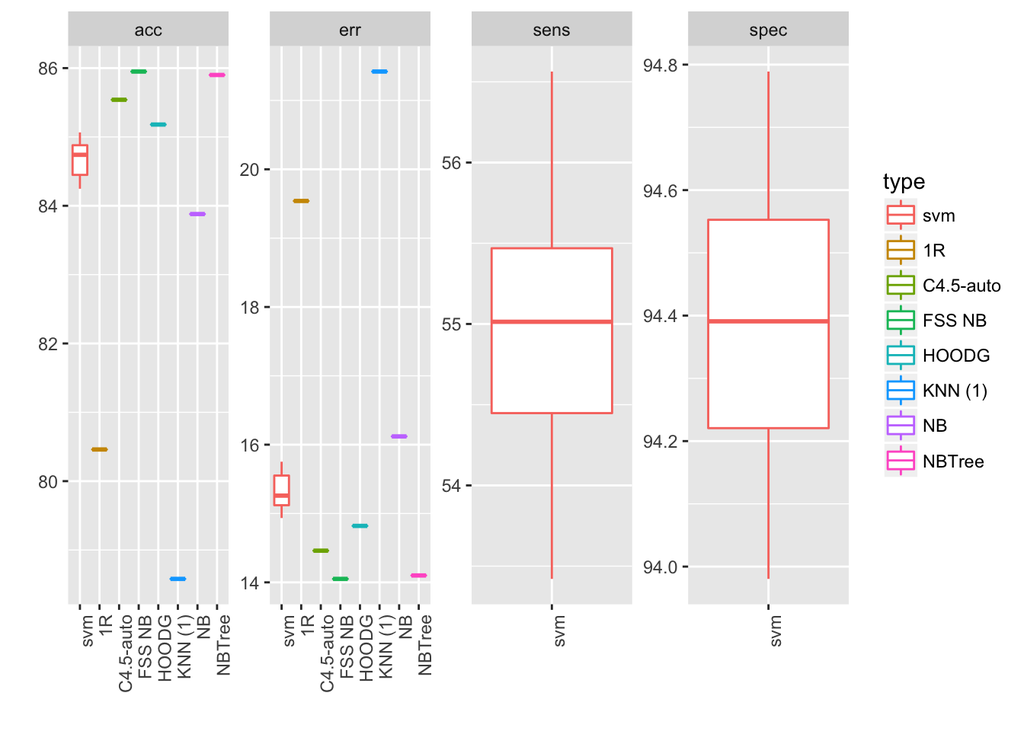

```r
bestKernel = tuneParamsFreq[1,"kernel"]
bestCost = tuneParamsFreq[1,"cost"]
bestDegree = tuneParamsFreq[1,"degree"]
bestGamma = tuneParamsFreq[1,"gamma"]

dfSvm <- NULL
for ( iSim in 1:nSim ) {

      trainIdx <- sample(nrow(data),0.67*nrow(data))

      #SVM
      svmTrain = svm(income~.,data=data[trainIdx,],
                     kernel=bestKernel,
                     cost=bestCost,
                     degree=bestDegree,
                     gamma=bestGamma)
      svmPred = predict(svmTrain,newdata=data[-trainIdx,])
      tmpVals = summPreds(as.numeric(svmPred),as.numeric(data[-trainIdx,"income"]))
      dfSvm = rbind(dfSvm,data.frame(type="svm",metric=names(tmpVals),value=tmpVals))
}
ggplot(rbind(dfSvm,dfTmp),aes(x=type,y=100*value,colour=type)) + geom_boxplot() + facet_wrap(~metric,ncol=4,scales="free") + xlab("") + ylab("") + theme(axis.text.x = element_text(angle = 90, hjust = 1))
```

```r
aggregate(value~metric, data=dfSvm, FUN=function(x) c(mn=mean(x)))
```

```
##   metric     value
## 1    acc 0.8467141
## 2    err 0.1532859
## 3   sens 0.5503677
## 4   spec 0.9438599
```

SVM returns better results than logistic regression but not as good as random forest by about 15.5% error rate. Other methods reported in the dataset description have comparable results. C4.5-auto, C4.5 rules, FSS NB, NBTree and IDTM have lower error rate. KNN1,3 had much higher error rate by about 20%.

As in previous methods in SVM, specificity is much higher than sensitivity by approximetaly 94%, 54% respectively.

# Problem 5: compare logistic regression, random forest and SVM model performance

Compare performance of the models developed above (logistic regression, random forest, SVM) in terms of their accuracy, error and sensitivity/specificity. Comment on differences and similarities between them.

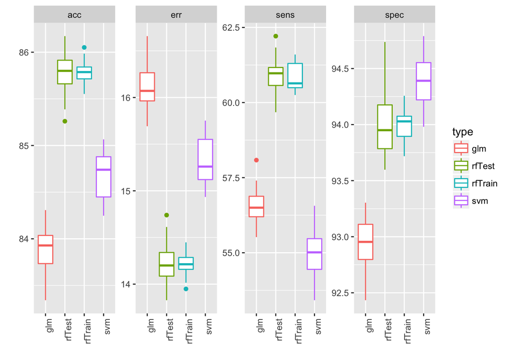

```r
ggplot(rbind(dfGlm,dfRf,dfSvm),aes(x=type,y=100*value,colour=type)) + geom_boxplot() + facet_wrap(~metric,ncol=4,scales="free") + xlab("") + ylab("") + theme(axis.text.x = element_text(angle = 90, hjust = 1))
```

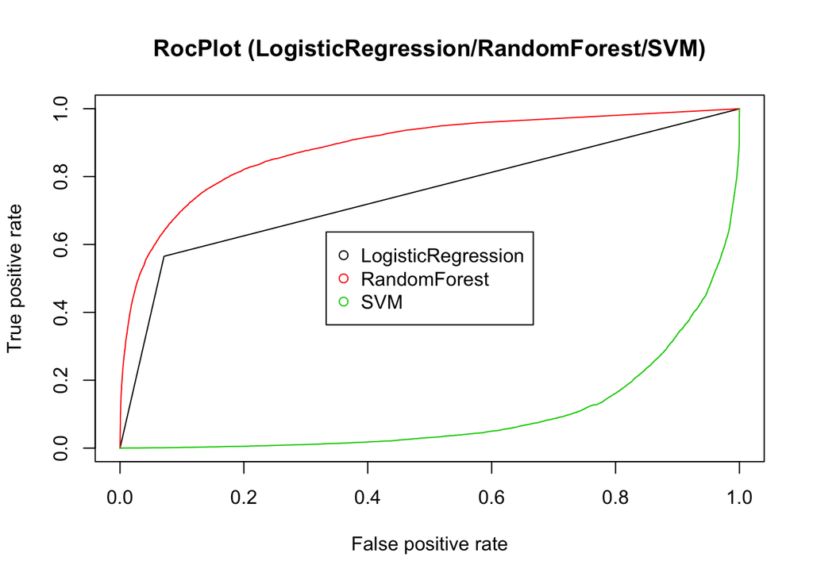

```r
svmFit = svm(income~.,data=data,
                     kernel=bestKernel,
                     cost=bestCost,
                     degree=bestDegree,
                     gamma=bestGamma)

glmPred <- predict(glmFit, newdata=data, type="response") > 0.5
rocplot((as.numeric(glmPred)+1), data[,"income"], main="RocPlot (LogisticRegression/RandomForest/SVM)",col=1)

rocplot(as.vector(rfFit$votes[,2]), data[,"income"], add=T,col=2)

fitted.svm = attributes(predict(svmFit,data, decision.values=TRUE))$decision.values
rocplot(fitted.svm, data[,"income"], add=T,col=3)
legend("center", legend = c("LogisticRegression","RandomForest","SVM"), col=1:3, pch=1)
```

Even if all methods return slighly different error rates. SVM performs better than other models in specificity. Error rate by logistic regression is higher than in other to methods. Overall random forest has highest accuracy.

# Extra: KNN model

Develop KNN model for this data, evaluate its performance for different values of $k$ on different splits of the data into training and test and compare it to the performance of other methods reported in the dataset description. Notice that this dataset includes many categorical variables as well as continuous attributes measured on different scales, so that the distance has to be defined to be meaningful (probably avoiding subtraction of the numerical values of multi-level factors directly or adding differences between untransformed age and capital gain/loss attributes).

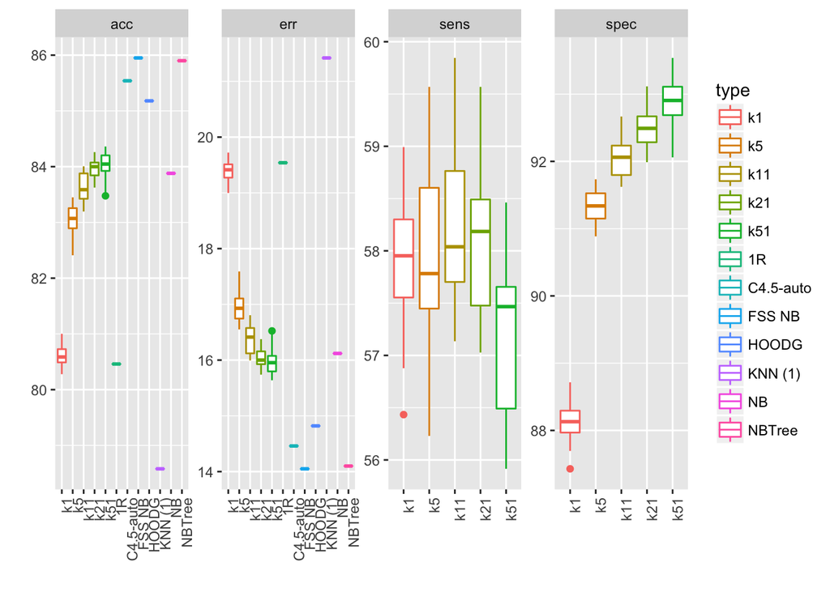

```r
#Converting categorical variables to binary
dataTmp = data
dataTmp$income = ifelse(as.character(dataTmp$income) == ">50K", 1, 0)
pca.formula = as.formula(paste0("~0+",paste0(colnames(dataTmp), collapse = "+")))
dataBinary = as.data.frame(model.matrix(pca.formula,data=dataTmp))

#Normalizing continious variables
dataBinary[,con.att] = lapply(dataBinary[,con.att], scale)

dfKnn <- NULL
for ( iSim in 1:nSim ) {
#print(iSim)
  trainIdx <- sample(nrow(dataBinary),0.67*nrow(dataBinary))
  for ( kTmp in c(1,5,11,21,51) ) {
#print(kTmp)
      knnTestPred <- knn(dataBinary[trainIdx,colnames(dataBinary)!="income"],dataBinary[-trainIdx,colnames(dataBinary)!="income"],dataBinary[trainIdx,"income"],k=kTmp)
      tmpVals <- summPreds(as.numeric(knnTestPred),as.numeric(dataBinary[-trainIdx,"income"]))
      dfKnn <- rbind(dfKnn,data.frame(type=paste0("k",kTmp),metric=names(tmpVals),value=tmpVals))
  }
}

ggplot(rbind(dfKnn,dfTmp),aes(x=type,y=100*value,colour=type)) + geom_boxplot() + facet_wrap(~metric,ncol=4,scales="free") + xlab("") + ylab("") + theme(axis.text.x = element_text(angle = 90, hjust = 1))
```

```r
aggregate(value~type+metric, data=dfKnn, FUN=function(x) c(mn=mean(x)))
```

```
##    type metric     value
## 1    k1    acc 0.8061662
## 2    k5    acc 0.8302776
## 3   k11    acc 0.8363767
## 4   k21    acc 0.8394749
## 5   k51    acc 0.8402964
## 6    k1    err 0.1938338
## 7    k5    err 0.1697224
## 8   k11    err 0.1636233
## 9   k21    err 0.1605251
## 10  k51    err 0.1597036
## 11   k1   sens 0.5787986
## 12   k5   sens 0.5791449
## 13  k11   sens 0.5822032
## 14  k21   sens 0.5810234
## 15  k51   sens 0.5717906
## 16   k1   spec 0.8812906
## 17   k5   spec 0.9132706
## 18  k11   spec 0.9203722
## 19  k21   spec 0.9248829
## 20  k51   spec 0.9290296
```

KNN in with k=1 returned almost identical result for KNN1,3 in data description, which is among worse results. Beginning from k=5 upto k=51 error rate decreases to approximetaly 16%. This result is comprabale with results of other methods.

# Extra: variable importance in SVM

SVM does not appear to provide readily available tools for judging relative importance of different attributes in the model. Please evaluate here an approach similar to that employed by random forest where importance of any given attribute is measured by the decrease in model performance upon randomization of the values for this attribute.

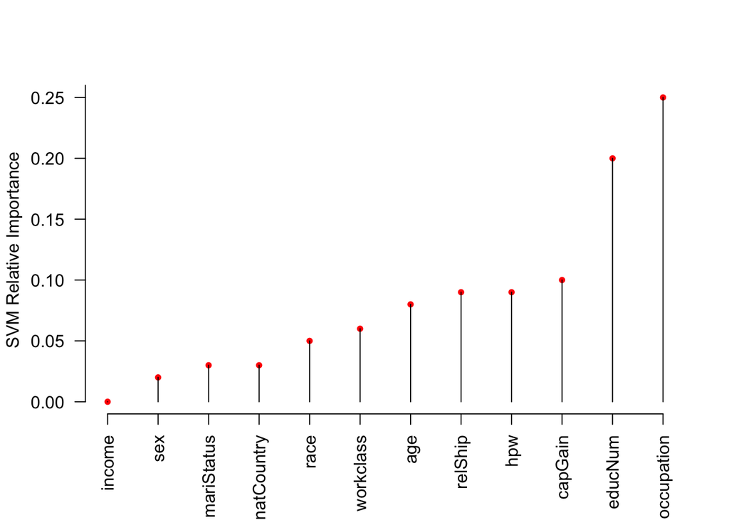

```r
#vanilladot-linear
#rbfdot-radial
#polydot-polynomial

#sigma-gamma
#c-cost
#d-degree

svmKernel = data.frame(kernel=c("vanilladot","rbfdot","polydot"))
rownames(svmKernel)=c("linear","radial","polynomial")

kparTmp = "automatic"
if(bestKernel=="radial") {
  kparTmp = list(sigma=bestGamma)
} else if(bestKernel=="polynomial") {
  kparTmp = list(d=bestDegree)
}


svmModel = fit(income~., data=data, model="svm",
               kernel=as.character(svmKernel[bestKernel,"kernel"]),
               C=bestCost,
               kpar=kparTmp
               )
svmImp = Importance(svmModel, data=data, method="1D-SA")

#Relative importance for each attribute
relImp = cbind(colnames(data), round(svmImp$imp,digits=2))
relImp = relImp[order(relImp[,2]),]

old.par = par(no.readonly = TRUE)
plot(relImp[,2], axes = 0,xlab="",ylab="SVM Relative Importance",pch=20,col="red")
lines(relImp[,2], type="h")
axis(1, at=seq(1,length(relImp[,1]),by=1),labels=relImp[,1],las=2)
axis(2, at=seq(0,0.3,by=0.05),las=1)
```

```r
par(old.par)
```

The plot presents relative importance for SVM model. It looks like the most important attributes are occupation and educNum Surprisingly mariStatus, sex, race, natCountry are less important.